# R Notebook

```r
library(CodeClanData)
```

```r
beer
```

| brand | brewer | percent | calories | carbohydrates |
| --- | --- | --- | --- | --- |
| Beamish Irish Cream Stout | Beamish - Crawford (Ireland) | 5.00 | 146 | 10.00 |
| Beck's Beer | Brauerei Beck (Germany) | 2.30 | 143 | 3.90 |
| Beck's Light | Brauerei Beck (Germany) | 4.80 | 64 | 11.00 |
| Dragon Stout | Desnoes - Goeddes (Jamaica) | 5.10 | 220 | 11.00 |
| Greenall's Cheshire English Pub Beer | Greenall Whitley PLC (England) | 5.00 | 142 | 9.50 |
| Guiness Draught - Bottle | Guinness (Ireland) | 4.27 | 126 | 17.40 |
| Harp | Harp (Ireland) | 5.00 | 142 | 11.50 |
| Heineken Special Dark Beer | Heineken (Holland) | 3.80 | 170 | 6.80 |
| Kronenbourg Imported Dark Beer | Kronenbourg (France) | 5.30 | 163 | 9.90 |
| O'Keefe Canadian Beer | O'Keefe (Canada) | 4.20 | 142 | 14.70 |

[output cut: 162 more lines]

```r
NA
```

the first thing I otice abot this data set is taht not all countries ar included. I also notice that country is contained within brackets rather than contained within its own data field. This would allow separation and identification of country of origin to be easier. a source would also be beneficial, to allow comparision of discrepancies between similar datasets. Also, brewer sub categorie could ba added to allow brand sun categories to be distinguished.

Alos there is no definition of quantities per measurement for percent, calories and carbohydrates. Although these seem to be univerrsal it makes it difficult to assess whether any mean, max or min values would be trustworthy, for this reason.

I think this probably shown in a data frame already. I will test this by doing the following:

```r
class(beer)
```

```
[1] "tbl_df"     "tbl"        "data.frame"
```

I can also further ivestigate he data using:

```r
str(beer)
```

```
Classes ‘tbl_df’, ‘tbl’ and 'data.frame':   172 obs. of  5 variables:
 $ brand        : chr  "Beamish Irish Cream Stout" "Beck's Beer" "Beck's Light" "Dragon Stout" ...
 $ brewer       : chr  "Beamish - Crawford (Ireland)" "Brauerei Beck (Germany)" "Brauerei Beck (Germany)" "Desnoes - Goeddes (Jamaica)" ...
 $ percent      : num  5 2.3 4.8 5.1 5 4.27 5 3.8 5.3 4.2 ...
 $ calories     : chr  "146" "143" "64" "220" ...
 $ carbohydrates: num  10 3.9 11 11 9.5 17.4 11.5 6.8 9.9 14.7 ...
 - attr(*, "na.action")= 'omit' Named int  1 2 3 4 8 9 10 11 12 13 ...
  ..- attr(*, "names")= chr  "1" "2" "3" "4" ...
```

This command confirms that it is indeed saved as a data frame.

I can calculate the mean percent value by doing the following:

```r
mean(beer[,3])
```

```
[1] 5.199884
```

This shows the mean percent value for all beers within that column.

mean calories:

```r
mean(beer[,4])#column 4 contains the calorie data
```

```
argument is not numeric or logical: returning NA
```

```
[1] NA
```

```r
mean(beer$percent)
```

```
[1] 5.199884
```

```r
?mean
```

```r
mean(beer[,4], trim = 0, na.rm = TRUE)
```

```
argument is not numeric or logical: returning NA
```

```
[1] NA
```

calculate mean for carbohydtrates:

```r
mean(beer$carbohydrates)
```

```
[1] 11.99302
```

Again this looks like a correct value.

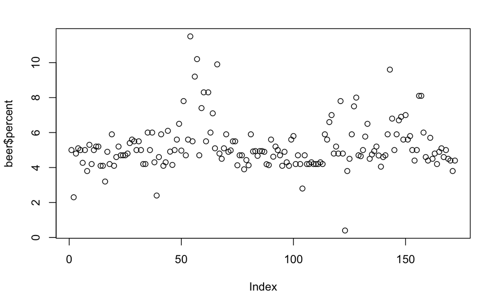

```r
plot(beer$percent)
```

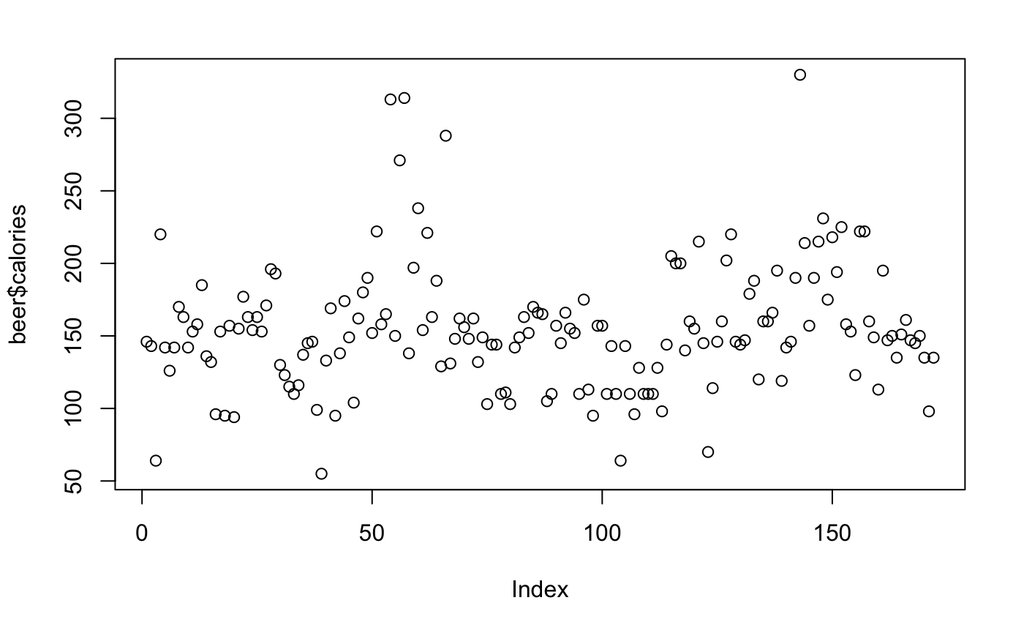

```r
plot(beer$calories)
```

```r
map_df(beer, sort)
```

| brand | brewer | percent | calories | carbohydrates |
| --- | --- | --- | --- | --- |
| American Amber Lager | Adolph Coors | 0.40 | 103 | 1.90 |
| American Lager | Adolph Coors | 2.30 | 103 | 2.40 |
| American Light | Adolph Coors | 2.40 | 104 | 2.60 |
| Anchor Steam | Adolph Coors | 2.80 | 105 | 2.60 |
| Anheuser Busch Natural Ice | Adolph Coors | 3.20 | 110 | 3.10 |
| Anheuser Busch Natural Light | Anchor | 3.80 | 110 | 3.20 |
| Aspen Edge | Anheuser Busch | 3.80 | 110 | 3.20 |
| Bard's Gold (Gluten-Free) | Anheuser Busch | 3.80 | 110 | 3.20 |
| Beamish Irish Cream Stout | Anheuser Busch | 3.90 | 110 | 3.50 |
| Beck's Beer | Anheuser Busch | 4.05 | 110 | 3.90 |

[output cut: 162 more lines]

```r
map(beer, length)
```

```
$brand
[1] 172

$brewer
[1] 172

$percent
[1] 172

$calories
[1] 172

$carbohydrates
[1] 172
```